# Altmetric Mentions

2018-07-26

A Mention (sometimes also called a *post* in Altmetric parlance) is a piece of content in which a specific article is mentioned. Collecting these mentions is pretty much the core piece of value that Altmetric add.

As ever, the most fun with Mentions can be had by joining them to the master Articles dataset. However, the Altmetric client also extracts Authors information from each Mention and adds it to a third dataset (see the Authors notebook for more about this set).

```r
arrange(
  summarise(
    group_by(
      filter(articles_with_mentions,
             source == "news"),
      journal_title
    ),
    total = n()
  ),
  desc(total)
)
```

```
# A tibble: 45 x 2
   journal_title                    total
   <chr>                            <int>
 1 The Lancet                         458
 2 Institute for Fiscal Studies       178
 3 Annals of Internal Medicine        109
 4 Journal of Cancer Policy            53
 5 Tobacco Control                     45
 6 Journal of Economic Perspectives    39
 7 Health Affairs                      34
 8 New England Journal of Medicine     33
 9 JAMA Oncology                       31
10 Journal of Clinical Oncology        22
# ... with 35 more rows
```

## Mentions Data Dictionary

The following fields are included in the Mentions dataset

### author_id

**Data type: character**

Used to join Mentions to the Authors dataset. Author information is extracted for each Mention and added to a separate set, which enables analysis of the engagement particular authors have with the Articles in the master dataset. For example, which papers have been mentioned by the Twitter users with the highest numbers of followers?

```r
arrange(
  summarise(
    group_by(filter(articles_with_mentions_and_authors, source == "twitter"),
    article_title),
    total_followers = sum(author_follower_count)
  ),
  desc(total_followers)
)
```

```
# A tibble: 205 x 2
   article_title                                                     total_followers
   <chr>                                                                       <int>
 1 Three-Year Impacts Of The Affordable Care Act: Improved Medical …         4201721
 2 Higher Education funding in England: past, present and options f…         3497734
 3 Teaching personal initiative beats traditional training in boost…         3438412
 4 Financing transformative health systems towards achievement of t…         3406705
 5 Global economic cost of smoking-attributable diseases                     3167965
 6 Dementia prevention, intervention, and care                               2409503
 7 Long-run comparisons of spending per pupil across different stag…         1953266
 8 Evolution and patterns of global health financing 1995–2014: dev…         1790594
 9 Update: Interim Guidance for Health Care Providers Caring for Pr…         1529194
10 Machine Learning: An Applied Econometric Approach                         1358519
# ... with 195 more rows
```

The above depends upon counting two tweets about one article by a twitter user with n followers as being tweeted at 2n followers. Given that not all followers of a twitter user see all the tweets that user posts, this seems a reasonable assumption.

### date_posted

**Data type: POSIX Calendar Time**

The date upon which the Mention was posted. This is incredibly useful for trending the timeline of the ‘buzz’ around a specific Article (in the case below, the most mentioned one in the test set - 10.1920/bn.ifs.2017.bn0211).

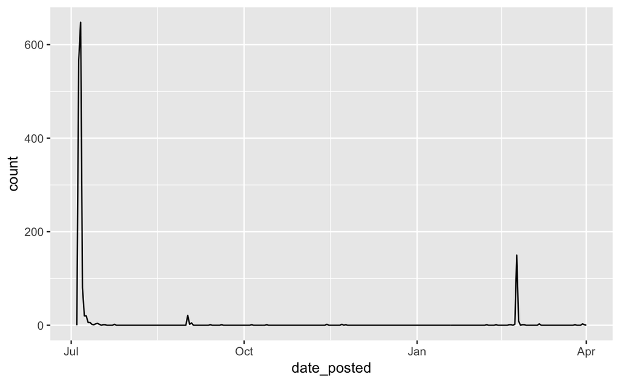

```r
article_mentions <- filter(mentions, doi == "10.1920/bn.ifs.2017.bn0211")
ggplot(data = article_mentions, mapping = aes(x = date_posted)) +
  geom_freqpoly(binwidth = 86400)
```

### doi

**Data type: character**

The key used to link a Mention back to the Article it mentioned in the master Articles set.

### source

**Data type: character**

The source of the Mention. These can be charted using the query below (Twitter usually swamps all the others at time of writing).

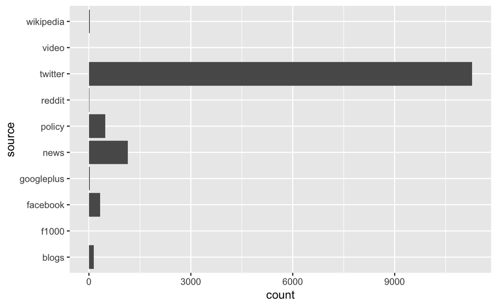

```r
ggplot(data = mentions) +
  geom_bar(mapping = aes(x = source)) +
  coord_flip()
```

### url

**Data type: character**

The URL of the Mention (i.e. the place on the internet that Altmetric found it).